# 201771

*N* removed NAs: 3

*N* removed typo: 1

*N* removed <18: 17

*N* total clean: 129

| Group | *N* | *M*<sub>age</sub> | *M*<sub>rating</sub> |
| --- | --- | --- | --- |
| Control | 69 | 21.19 | 6.59 |
| Experim | 60 | 21.32 | 5.37 |

**Main analysis results**

*t*(127) = 8.59, *p* < .001

[interactive chart not shown]

[figure not shown]

[interactive chart not shown]

# 201771

Analysing Data, Spring 2020

# Methods

## Participants

Table 1 *Descriptive Statistics by Condition*

| CONDITION | *N* | % | *M*~age | *SD*<sub>age</sub> |
| --- | --- | --- | --- | --- |
| control | 69 | 53.49 | 21.19 | 2.24 |
| experimental | 60 | 46.51 | 21.32 | 1.78 |

## Design

The purpose of this research was to examine our hypothesis concerning whether or not colour influences attractiveness. Our variables were colour, and ratings of attractiveness. Colur is an independent categorical variable; it is a factor with two levels, red (the experimental condition) and white (the control condition). Colour is also the predictor as it is the variable which we are manipulating. Ratings of Attractiveness is a continuous variable. There were three different questions asked to participants in order to measure ratings of attractiveness, these were; “How atteactive do you think this person is?”, “How pleasant is this person to look at?” and “If I were to meet the person in this picture face to face, I would think he is attractive”. Each question was measured on a 9 point scale, ranging from 1 (not attractive at all) to 9 (extremely attractive). The purpose of the study was to understand whether viewing a different colour frame around an image of a moderately attractive man influences the mean ratings of his attactiveness. This will be analysed using the statistical *t*-test, in order to see whether the difference in means is significant.

# Results

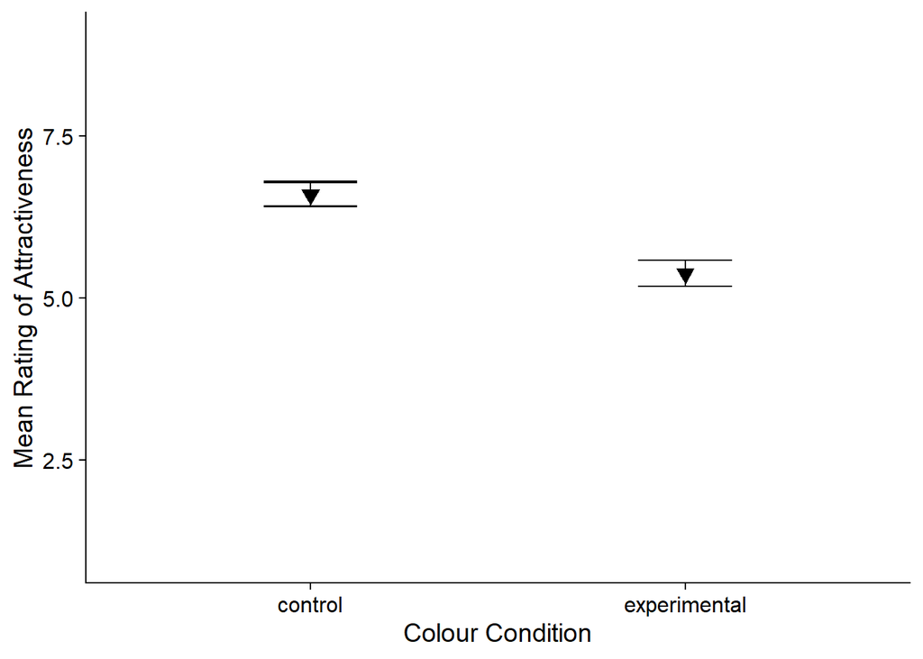

# Discussion

In this present research, we aimed to investigate the effect of colour and how it can potentially influence ratings of attractiveness, specifically with regard to how women perceive men. Our study combined the mean attractiveness ratings given by participants who either took part in the red condition, in which they viewed photos of moderately attractive men within a red frame, or the white condition, in which they viewed moderately attractive men within a white frame, chosen because white is the most unobtrusive of colours in the experimental paradigm (Elliot et al, 2010). Participants were then asked to answer three different questions concerning the attractiveness of the men in these photos, rating them on a scale of 1-9 for each question. We aimed to understand whether having a red frame caused participants to rate the men in those photos as being more attractive in comparison to the white frame, in line with previous research surrounding the hypothesised ‘red effect’ (Elliot et al, 2010, Elliot & Niesta, 2008).  
Our data indicated that there was a significant difference in mean attractiveness ratings between the two groups, however not in the way that previous research would suggest. In our study, those participants in the white condition had an overall higher mean rating of attractiveness compared to those in the red group, implying that having a white background actually increased perceived ratings of attractiveness. These results directly contradict many of the results and concepts of the previous research in this field; love and passion has been linked to the colour red consistently over many cultures (Adams & Osgood, 1973), as well as having been linked to concepts of power, authority, strength, dominance and wealth (Wexner, 1954; Schaie, 1961; Little & Hill, 2007; cited in Elliot et al 2008). In animals and non-human primates, males with the deepest red colours have consistently been shown to have a reproductive advantage over their less-intensely coloured counterparts (Yasukawa, Butler & Enstrom, 2009). Having identified this proposed ‘red effect’ across cultures and even amongst non-human primates, it is a basis to hypothesise that the colour red would have some influence on attractiveness ratings. This study was based upon Elliot et al’s original 2010 study, with the same variables and study design; therefore it is interesting that our results show the opposite to what the original study results indicate; Elliot et al’s results provided strong support for the hypothesised red effect (2010). It should be noted however, that Elliot et al’s original study on which our study was based, has come under scrutiny for containing publication bias, which could account for our inconsistency in findings when compared with the original study. Hesslinger, Goldbach & Carbon also replicated Elliot et al’s 2010 study, and reported that neither of their replications yielded a statistically significant effect of the colour red on the dependent variables (2015), implying that the red effect was not as prominent as Elliot et al’s studies indicate. Francis (2013) proposed that Elliot et al’s results may contain some publication bias which could potentially distort the literature surrounding the ‘red effect’, causing it to seem more reputable than it actually is (Francis, 2013). There are limitations of this study. Firstly, the initial participation of unethically aged participants under the age of 18 resulted in a smaller sample size in the study compared with the original collected data. This means that individual differences of participants will have most likely had a greater impact on the data due to the smaller sample size. Secondly, another study found that the hypothesised red effect was strong only for women who were at a time of higher conception probability; they reported stronger sexual desire for the man surrounded by red compared to those at a low conception probability for whom this red effect was not found at all. The effect was significant only when the categorical “fertile window” (days 9–14) was calculated using the forward counting method from last menstrual onset (Prokop, Pazda & Elliot, 2015). This could potentially be an unforeseen confounding variable affecting attractiveness ratings given by women, meaning that attractiveness ratings were not influenced by the colour red itself, but how sensitive the woman was to it at the time.  
Future studies may want to investigate the effect of red skin pigmentation, perhaps involving using three different photos of a moderately attractive man, subtly modified to redden the colour of their skin. This would help to increase generalisability in findings, and understand whether the results seen in the reproductive advantage of deeper red skin pigmentation for non-human primates is at all transferrable to human perceived ratings of attractiveness (Elliot et al, 2010) Future studies may also want to investigate further into the effect of the female ovulatory cycle on ratings of attractiveness, and subsequent susceptibility to red stimuli. The results of our study were different from that of the original Elliot et al’s 2010 study, we found the mean ratings of perceived attractiveness to be higher in the control condition compared to the experimental condition. We have examined why this may have occurred, as well as limitations of our study and some possible avenues for future research.

# References

Adams, F., & Osgood, C. (1973). A Cross-Cultural Study of the Affective Meanings of Color. Journal Of Cross-Cultural Psychology, 4(2), 135-156. doi: 10.1177/002202217300400201

Elliot, A. J., & Niesta, D. (2008). Romantic Red: Red enhances men’sattraction to women. Journal of Personality and Social Psychology, 95, 1150-1164

Elliot, A., Niesta Kayser, D., Greitemeyer, T., Lichtenfeld, S., Gramzow, R., Maier, M., & Liu, H. (2010). Red, rank, and romance in women viewing men. Journal Of Experimental Psychology: General, 139(3), 399-417. doi: 10.1037/a0019689

Francis, G. (2013). Publication bias in “Red, rank, and romance in women viewing men,” by Elliot et al. (2010). Journal Of Experimental Psychology: General, 142(1), 292-296. doi: 10.1037/a0027923

Hesslinger, V., Goldbach, L., & Carbon, C. (2015). Men in red: A reexamination of the red-attractiveness effect. Psychonomic Bulletin & Review, 22(4), 1142-1148. doi: 10.3758/s13423-015-0866-8

Prokop, P., Pazda, A., & Elliot, A. (2015). Influence of conception risk and sociosexuality on female attraction to male red. Personality And Individual Differences, 87, 166-170. doi: 10.1016/j.paid.2015.07.042

Yasukawa, K., Butler, L., & Enstrom, D. (2009). Intersexual and intrasexual consequences of epaulet colour in male red-winged blackbirds: an experimental approach. Animal Behaviour, 77(2), 531-540. doi: 10.1016/j.anbehav.2008.11.013